# Herramientas Computacionales para la Investigación Interdisciplinaria Reproducible

- Profesor: [Dr. José Manuel Magallanes, PhD](http://www.pucp.edu.pe/profesor/jose-manuel-magallanes/) (jmagallanes@pucp.edu.pe)  
  Profesor del **Departamento de Ciencias Sociales, Pontificia Universidad Católica del Peru**.  
  Senior Data Scientist del **eScience Institute** and Visiting Professor at **Evans School of Public Policy and Governance, University of Washington**.  
  Fellow Catalyst, **Berkeley Initiative for Transparency in Social Sciences, UC Berkeley**.

## Sesión 3: Integración

En esta sesión final, vamos a utilizar el archivo que se creó en Python, donde hay diversos indicadores políticos a nivel de país. El archivo en cuestión será analizado en R, usando RStudio.

RStudio es un entorno para usar R. Pero lo peculiar es que no sólo permite usar un archivo clásico de sintaxis (para lo cual RStudio es menos relevante), sino que también puede producir documentos en formato HTML y PDF. En este caso, veremos como convertir un archivo de códigos simples de R en un archivo más ‘sofisticado’. Este archivo sofisticado combinará código de R y Latex, para producir un PDF.

Dado que usaremos Latex desde RStudio, podemos tomar el control detallado de lo que queremos mostrar en el PDF final. En nuestro caso, no sólo veremos detalles de cómo producir lo que R genera, sino que además lo integraremos con un archivo de referencias bibliográficas producido desde Zotero; almacenaremos todo en GitHub; y veremos cómo conectar este repositorio con Overleaf para compartir versiones intermedias con usuarios menos especializados.

Nótese que cada vez que llamo a un ‘paquete’ de R usaré el comando **library**; este comando sólo activa un paquete (o biblioteca) si es que esta está previamente *instalada*. Para instalar debes usar el menu **Tools** y elige la opción **install.packages**.

## Comandos básicos en R para exploración Univariada:

```r
# carga de datos
filename="indexes.csv"
dataidx=read.csv(filename,
                 stringsAsFactors = FALSE)

# ver primeras filas los datos:
head(dataidx)
```

```
##       Country WorldFreedom EconomicFreedom PressFreedom Democracy
## 1    Abkhazia            3               2            3         2
## 2 Afghanistan            1               2            2         1
## 3     Albania            3               3            3         2
## 4     Algeria            1               1            2         1
## 5     Andorra            5               3            4         4
## 6      Angola            1               1            2         1
```

Los datos ya llegaron ‘limpios’ desde Python.

Como tenemos números en vez de factores, podemos preparar etiquetas para las gráficas:

```r
# creando etiquetas:
level5=c("muy malo","malo","medio","bueno","muy bueno")
level4=c("muy malo","malo","bueno","muy bueno")
level3=c("muy malo","medio","muy bueno")
```

Aquí podemos ver la distribución de una variable:

```r
demoTable=table(dataidx[,5])
demoTable
```

```
##
##  1  2  4  5
## 60 45 82 19
```

De ahí que:

```r
demoTable=table(dataidx[,5])
names(demoTable)=level4
demoTable
```

```
##  muy malo      malo     bueno muy bueno
##        60        45        82        19
```

Ahora las frecuencias relativas:

```r
demoTableRel=round(prop.table(demoTable)*100,1)
demoTableRel
```

```
##  muy malo      malo     bueno muy bueno
##      29.1      21.8      39.8       9.2
```

Y aquí el plot que representa esta distribución:

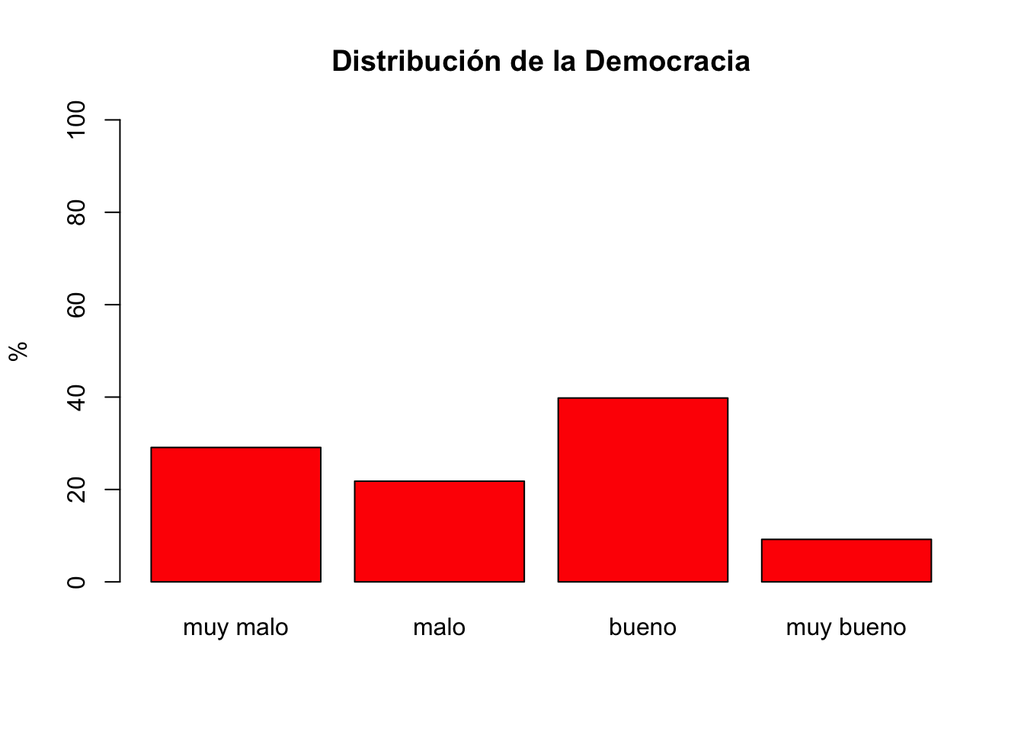

```r
title='Distribución de la Democracia'
paleta='red'
barplot(demoTableRel,main=title,
        col=paleta,ylim = c(0,100),
        ylab = "%")
```

Los mismo hacemos para ver la Libertad económica en el mundo en una tabla:

```r
ecoTable=table(dataidx[,3])
names(ecoTable)=level5
ecoTable
```

```
##  muy malo      malo     medio     bueno muy bueno
##        21        78        74        28         6
```

Sus frecuencias relativas:

```r
ecoTableRel=round(prop.table(ecoTable)*100,1)
ecoTableRel
```

```
##  muy malo      malo     medio     bueno muy bueno
##      10.1      37.7      35.7      13.5       2.9
```

Y aquí el plot:

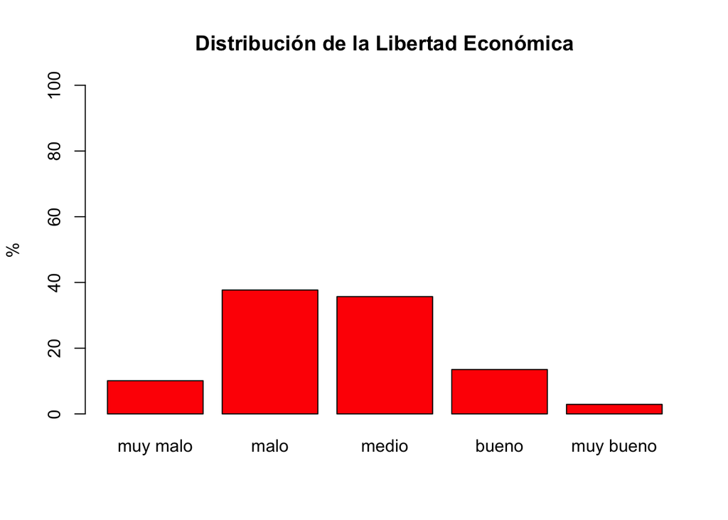

```r
title='Distribución de la Libertad Económica'
paleta='red'
barplot(ecoTableRel,main=title,
        col=paleta,ylim = c(0,100),
        ylab = "%")
```

La Libertad general en el mundo en una tabla:

```r
worldTable=table(dataidx[,2])
names(worldTable)=level3
worldTable
```

```
##  muy malo     medio muy bueno
##        55        62        89
```

Ahora las frecuencias relativas:

```r
worldTableRel=round(prop.table(worldTable)*100,1)
worldTableRel
```

```
##  muy malo     medio muy bueno
##      26.7      30.1      43.2
```

Y aquí el plot:

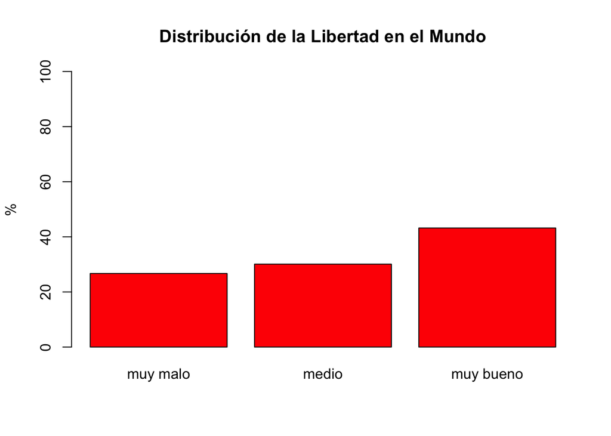

```r
title='Distribución de la Libertad en el Mundo'
paleta='red'
barplot(worldTableRel,main=title,
        col=paleta,ylim = c(0,100),
        ylab = "%")
```

La Libertad de prensa en el mundo en una tabla:

```r
pressTable=table(dataidx[,4])
names(pressTable)=level5
pressTable
```

```
##  muy malo      malo     medio     bueno muy bueno
##        22        53        66        48        17
```

Sus frecuencias relativas:

```r
pressTableRel=round(prop.table(pressTable)*100,1)
pressTableRel
```

```
##  muy malo      malo     medio     bueno muy bueno
##      10.7      25.7      32.0      23.3       8.3
```

Y aquí el plot que representa esta distribución:

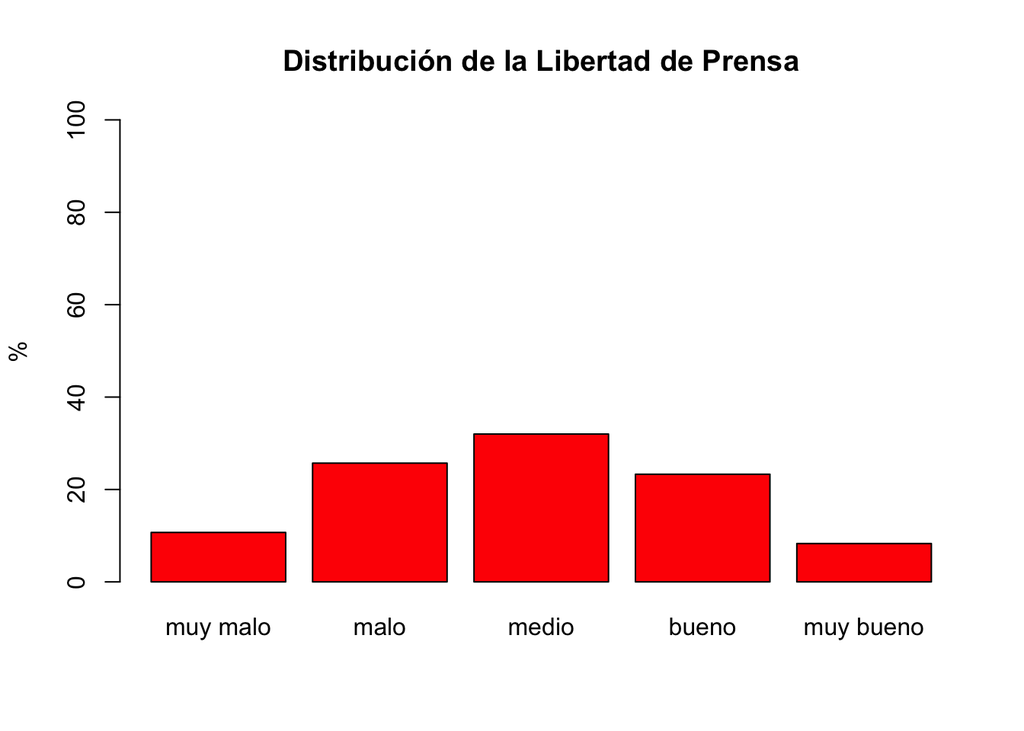

```r
title='Distribución de la Libertad de Prensa'
paleta='red'
barplot(pressTableRel,main=title,
        col=paleta,ylim = c(0,100),
        ylab = "%")
```

Podemos mostrar los estadísticos de cada variable:

```r
summary(dataidx[,-1])
```

```
##   WorldFreedom  EconomicFreedom  PressFreedom     Democracy
##  Min.   :1.00   Min.   :1.000   Min.   :1.000   Min.   :1.000
##  1st Qu.:1.00   1st Qu.:2.000   1st Qu.:2.000   1st Qu.:1.000
##  Median :3.00   Median :3.000   Median :3.000   Median :2.000
##  Mean   :3.33   Mean   :2.614   Mean   :2.927   Mean   :2.782
##  3rd Qu.:5.00   3rd Qu.:3.000   3rd Qu.:4.000   3rd Qu.:4.000
##  Max.   :5.00   Max.   :5.000   Max.   :5.000   Max.   :5.000
##  NA's   :1                      NA's   :1       NA's   :1
```

## Comandos básicos en R para exploración Bivariada:

Si asumimos que estamos interesados en el impacto de los otros indices en el nivel de Democracia, podemos primero ver la relación que tiene esta variable con todas las demás:

```r
explanans=names(dataidx)[c(2:4)]
corrDem=cor(x=dataidx[,5],
            y=dataidx[,explanans],
            use = "na.or.complete",
            method = "spearman")
corrDem
```

```
##      WorldFreedom EconomicFreedom PressFreedom
## [1,]    0.8964068       0.6021479    0.7821048
```

Veamos la correlación entre las variables independientes:

```r
corrTable=round(cor(dataidx[explanans],
               use = "na.or.complete"),2)

# ocultar media matriz
corrTable[upper.tri(corrTable)]<-""
as.data.frame(corrTable)
```

```
##                 WorldFreedom EconomicFreedom PressFreedom
## WorldFreedom               1
## EconomicFreedom         0.49               1
## PressFreedom            0.83            0.53            1
```

Finalmente, vemos los modelos propuestos. Primero sin la libertad mundial como independiente:

```r
LinRegA = lm(Democracy ~ ., data = dataidx[,c(3:5)])
summary(LinRegA)
```

```
##
## Call:
## lm(formula = Democracy ~ ., data = dataidx[, c(3:5)])
##
## Residuals:
##      Min       1Q   Median       3Q      Max
## -1.99066 -0.61319  0.05363  0.43110  2.22022
##
## Coefficients:
##                 Estimate Std. Error t value Pr(>|t|)
## (Intercept)     -0.64197    0.19912  -3.224  0.00147 **
## EconomicFreedom  0.37747    0.07736   4.879 2.15e-06 ***
## PressFreedom     0.83341    0.06509  12.804  < 2e-16 ***
## ---
## Signif. codes:  0 '***' 0.001 '**' 0.01 '*' 0.05 '.' 0.1 ' ' 1
##
## Residual standard error: 0.88 on 203 degrees of freedom
##   (1 observation deleted due to missingness)
## Multiple R-squared:  0.6371, Adjusted R-squared:  0.6335
## F-statistic: 178.2 on 2 and 203 DF,  p-value: < 2.2e-16
```

Luego con la libertad mundial

```r
LinRegB = lm(Democracy ~ ., data = dataidx[,c(2:5)])
summary(LinRegB)
```

```
##
## Call:
## lm(formula = Democracy ~ ., data = dataidx[, c(2:5)])
##
## Residuals:
##      Min       1Q   Median       3Q      Max
## -1.78162 -0.36268 -0.07215  0.30011  1.91679
##
## Coefficients:
##                 Estimate Std. Error t value Pr(>|t|)
## (Intercept)     -0.35412    0.13782  -2.569   0.0109 *
## WorldFreedom     0.70394    0.04642  15.164  < 2e-16 ***
## EconomicFreedom  0.29053    0.05335   5.446 1.49e-07 ***
## PressFreedom     0.01166    0.07020   0.166   0.8683
## ---
## Signif. codes:  0 '***' 0.001 '**' 0.01 '*' 0.05 '.' 0.1 ' ' 1
##
## Residual standard error: 0.6033 on 202 degrees of freedom
##   (1 observation deleted due to missingness)
## Multiple R-squared:  0.8303, Adjusted R-squared:  0.8278
## F-statistic: 329.4 on 3 and 202 DF,  p-value: < 2.2e-16
```

## Otros plots importantes

Podemos pintar un mapa con la información que tenemos. Veamos primero el mapa:

```r
library(rgdal)
```

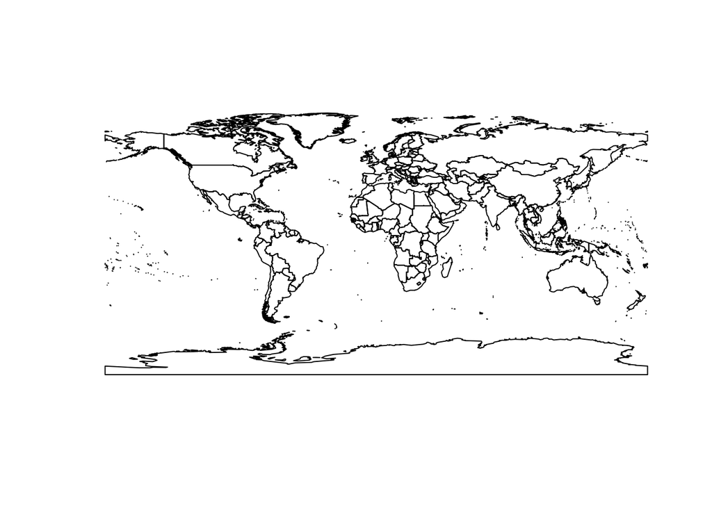

```r
folder='world_map'
file='world_map.shp'
mapaFile=file.path(folder,file)
mapaMundo = rgdal::readOGR(mapaFile,stringsAsFactors=F)
plot(mapaMundo)
```

Para pintarlo, podemos crear conglomerados. Tenemos para ello que juntar añadir la información de los índices al mapa (no al revés). Veamos cuales son las claves:

```r
head(mapaMundo@data)
```

```
##   FIPS ISO2 ISO3 UN                NAME   AREA  POP2005 REGION SUBREGION
## 0   AC   AG  ATG 28 Antigua and Barbuda     44    83039     19        29
## 1   AG   DZ  DZA 12             Algeria 238174 32854159      2        15
## 2   AJ   AZ  AZE 31          Azerbaijan   8260  8352021    142       145
## 3   AL   AL  ALB  8             Albania   2740  3153731    150        39
## 4   AM   AM  ARM 51             Armenia   2820  3017661    142       145
## 5   AO   AO  AGO 24              Angola 124670 16095214      2        17
##       LON     LAT
## 0 -61.783  17.078
## 1   2.632  28.163
## 2  47.395  40.430
## 3  20.068  41.143
## 4  44.563  40.534
## 5  17.544 -12.296
```

Usamos el campo respectivo para juntar los datos:

```r
# añadiendo información de indices al mapa:
mapaMundoAll=merge(mapaMundo,
                   dataidx,
                   by.x='NAME',
                   by.y='Country',all.x=F)
```

De ahí hagamos varios pasos:

```r
# nombres de las variables a utilizar
dimensions=c("EconomicFreedom","PressFreedom","Democracy")
```

```r
#creando subconjunto
dataCluster=mapaMundoAll@data[,c(dimensions)]
```

```r
# indicando que la data numerica es ordinal:
dataCluster=as.data.frame(lapply(dataCluster,as.ordered))
```

```r
# llamando librería:
library(cluster)

# creando matriz de distancias
dist=daisy(dataCluster,metric = "gower")

# aplicando algoritmo
pam_fit <- pam(dist, diss = TRUE, k = 3)

# añadiendo los clusters al mapa:
mapaMundoAll$cluster=pam_fit$clustering
```

Ya tenemos los clusters, pero hay que recordar que los números asignados no son necesariamente ‘reveladores’:

```r
aggregate(Democracy~cluster,
          data=mapaMundoAll,
          FUN=mean,
          na.rm=T)
```

```
##   cluster Democracy
## 1       1  3.805195
## 2       2  1.465753
## 3       3  4.266667
```

Luego, debemos recodificar la columna cluster:

```r
library(car)
mapaMundoAll$cluster<-recode(mapaMundoAll$cluster,
                             "1=2;2=3;3=1")
```

Con los clusters calculados, podemos pintar el mundo:

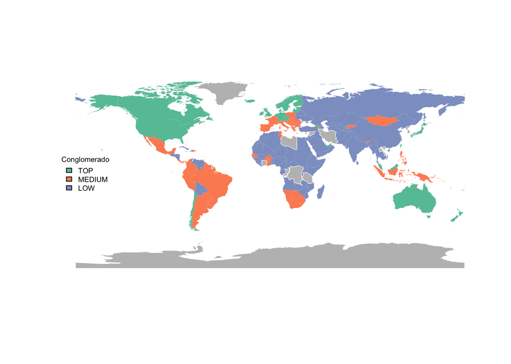

```r
# que se pintara:
varToPlot=mapaMundoAll$cluster

#cuantos colores:
numberOfColors = length(unique(varToPlot))

#qué colores:
library(RColorBrewer)
colorForScale='Set2'
paleta = brewer.pal(numberOfColors, colorForScale)

# a dibujar:
plot(mapaMundo,col='grey',border=0)
plot(mapaMundoAll, col = paleta[varToPlot],border=F,add=T)
legend('left', legend = c("TOP","MEDIUM","LOW"),
       fill = paleta,
       cex = 0.6,
       bty = "n",
       title="Conglomerado")
```

[Volver al curso](https://reproducibilidad.github.io/tallerPeru/)

**AUSPICIO**:

El desarrollo de estos contenidos ha sido posible gracias al grant del Berkeley Initiative for Transparency in the Social Sciences (BITSS) at the Center for Effective Global Action (CEGA) at the University of California, Berkeley

[figure not shown]

**RECONOCIMIENTO**

El autor reconoce el apoyo que el eScience Institute de la Universidad de Washington le ha brindado desde el 2015 para desarrollar su investigación en Ciencia de Datos.

[figure not shown]